# Efficiency Analysis

Jack Van Zeeland - Quality Intern 2023

July 18, 2023

# EFFICIENCY STYLE

## Grind

### TIME PERIOD

#### All

All Grind Efficiecy Summary

| shift | pounds | hours | efficiency | shifts | initial | na | err |
| --- | --- | --- | --- | --- | --- | --- | --- |
| A | 793471.0 | 510.55 | 1554.15 | 78 | 98 | 20 | 0 |
| B | 590283.0 | 294.29 | 2005.79 | 56 | 99 | 42 | 1 |
| C | 950500.0 | 647.05 | 1468.97 | 77 | 97 | 17 | 3 |
| D | 714516.8 | 489.31 | 1460.25 | 59 | 100 | 33 | 8 |

- EFFICIENCY: pounds/hours
- SHIFTS: shifts included in the data
- INITIAL: shifts since 2023
- NA: shifts with missing values
- ERR: shifts with erroneous values

##### SHIFT

###### All

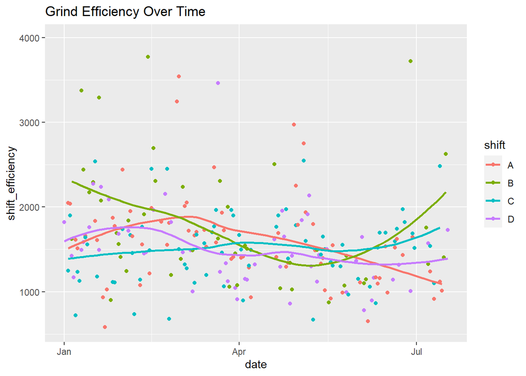

_____________________________________________________________________________________________________________________________________

###### A

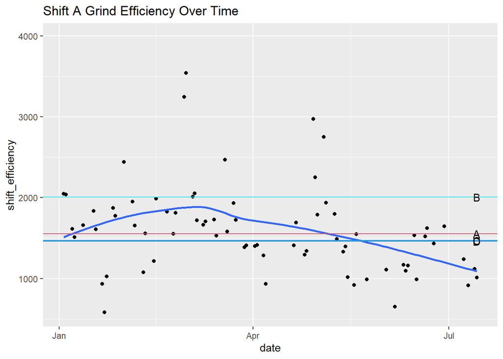

_____________________________________________________________________________________________________________________________________

###### B

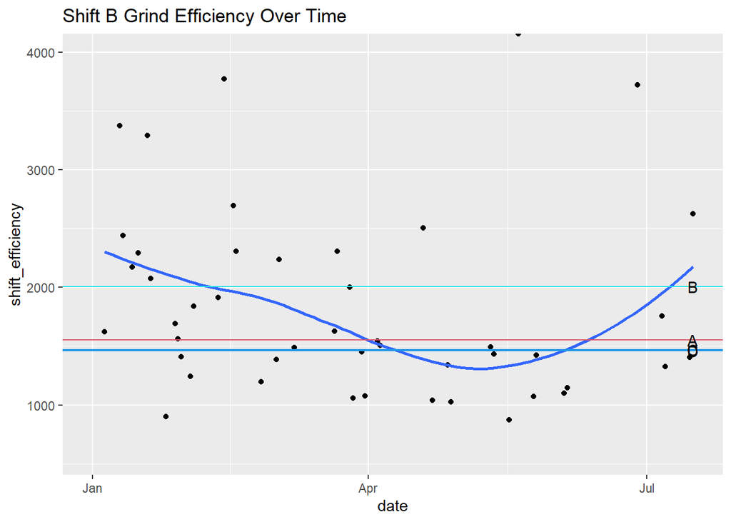

_____________________________________________________________________________________________________________________________________

###### C

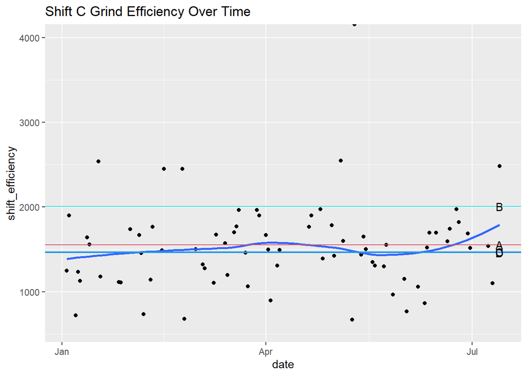

_____________________________________________________________________________________________________________________________________

###### D

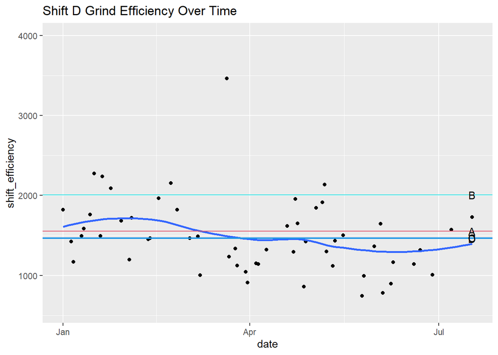

_____________________________________________________________________________________________________________________________________

#### January

January Grind Efficiecy Summary

| shift | pounds | hours | efficiency | shifts | initial | na | err |
| --- | --- | --- | --- | --- | --- | --- | --- |
| A | 127157 | 80.13 | 1586.88 | 13 | 15 | 2 | 0 |
| B | 188893 | 77.30 | 2443.64 | 12 | 16 | 4 | 0 |
| C | 148108 | 112.79 | 1313.13 | 13 | 15 | 2 | 0 |
| D | 186384 | 112.58 | 1655.57 | 12 | 16 | 3 | 1 |

- EFFICIENCY: pounds/hours
- SHIFTS: shifts included in the data
- INITIAL: shifts since 2023
- NA: shifts with missing values
- ERR: shifts with erroneous values

##### SHIFT

###### All

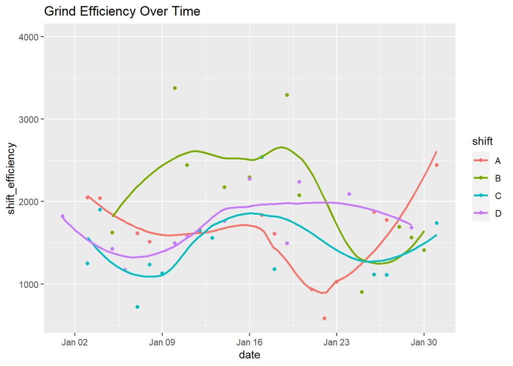

_____________________________________________________________________________________________________________________________________

###### A

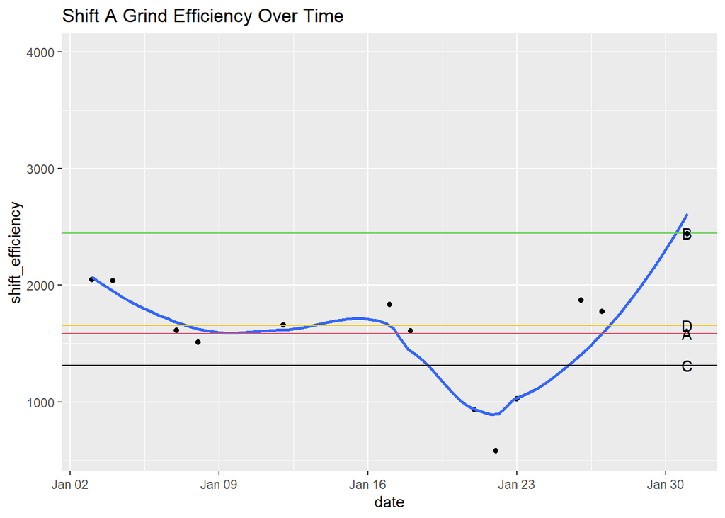

_____________________________________________________________________________________________________________________________________

###### B

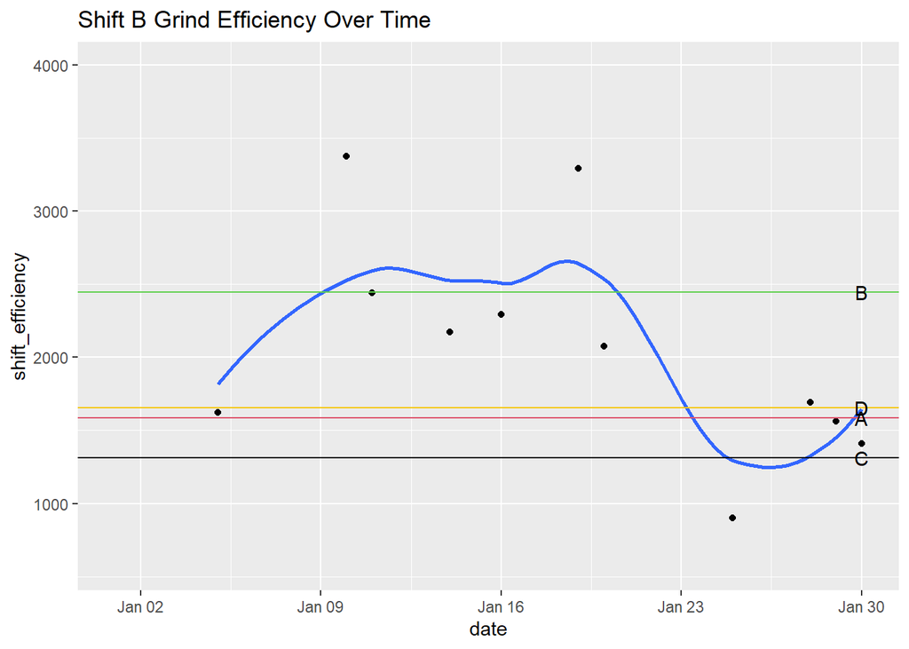

_____________________________________________________________________________________________________________________________________

###### C

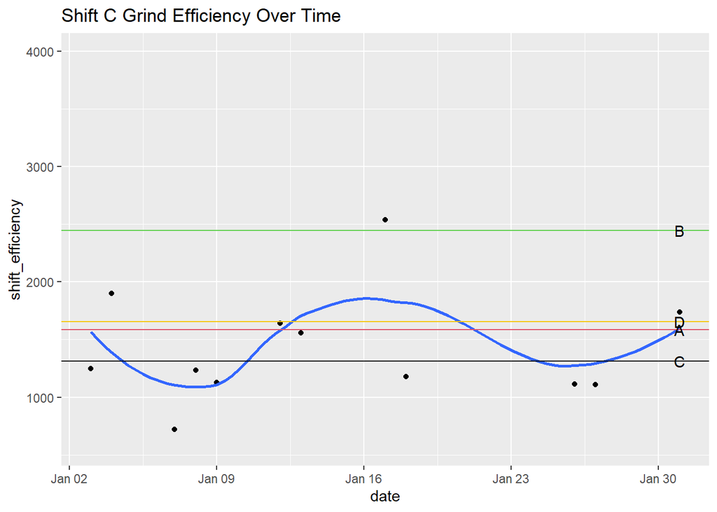

_____________________________________________________________________________________________________________________________________

###### D

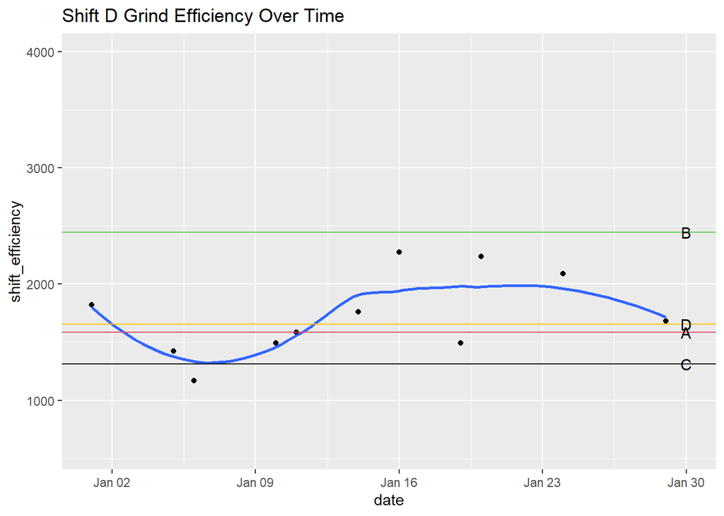

_____________________________________________________________________________________________________________________________________

#### February

February Grind Efficiecy Summary

| shift | pounds | hours | efficiency | shifts | initial | na | err |
| --- | --- | --- | --- | --- | --- | --- | --- |
| A | 88636.00 | 51.48 | 1721.76 | 10 | 14 | 4 | 0 |
| B | 69617.00 | 32.89 | 2116.66 | 7 | 14 | 7 | 0 |
| C | 144416.00 | 91.58 | 1576.94 | 12 | 14 | 2 | 0 |
| D | 80664.98 | 61.90 | 1303.15 | 8 | 14 | 5 | 1 |

- EFFICIENCY: pounds/hours
- SHIFTS: shifts included in the data
- INITIAL: shifts since 2023
- NA: shifts with missing values
- ERR: shifts with erroneous values

##### SHIFT

###### All

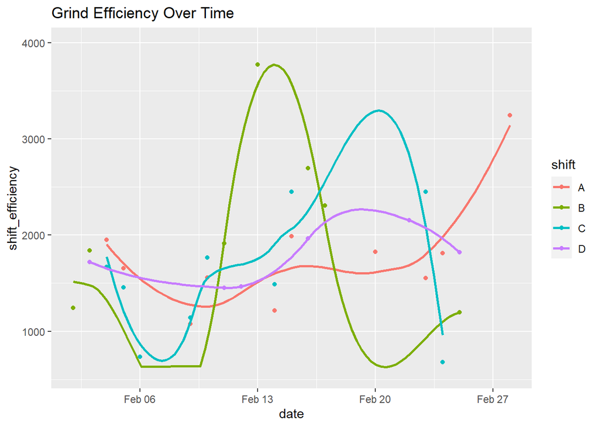

_____________________________________________________________________________________________________________________________________

###### A

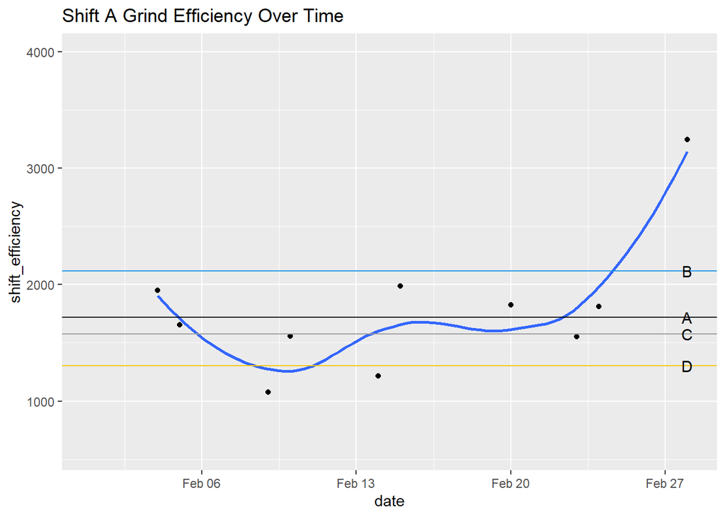

_____________________________________________________________________________________________________________________________________

###### B

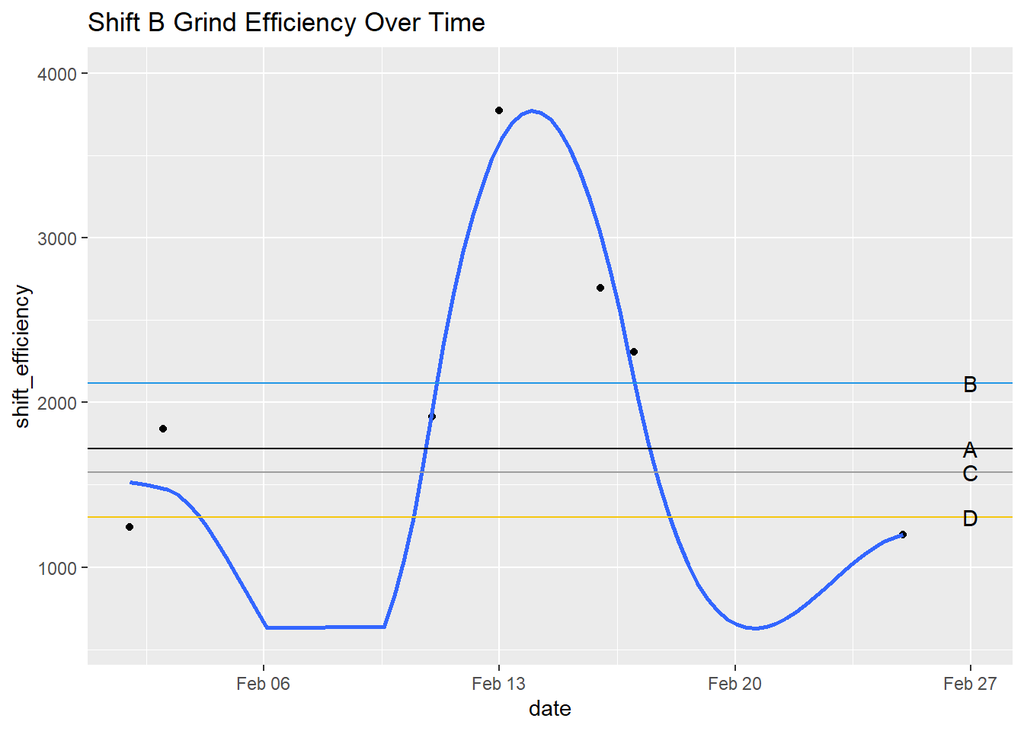

_____________________________________________________________________________________________________________________________________

###### C

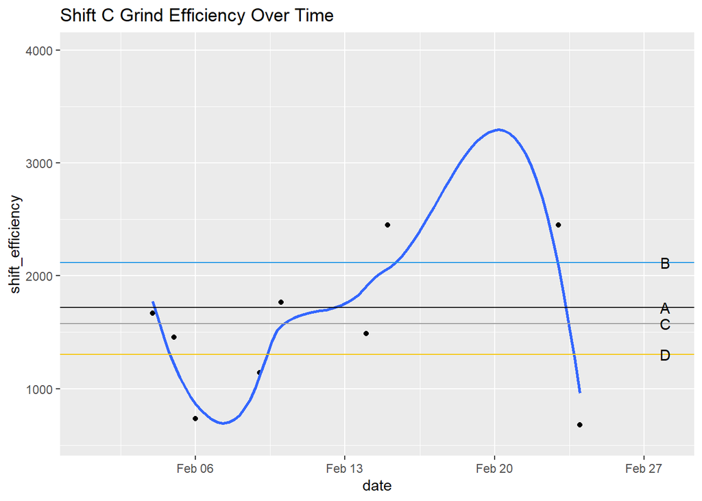

_____________________________________________________________________________________________________________________________________

###### D

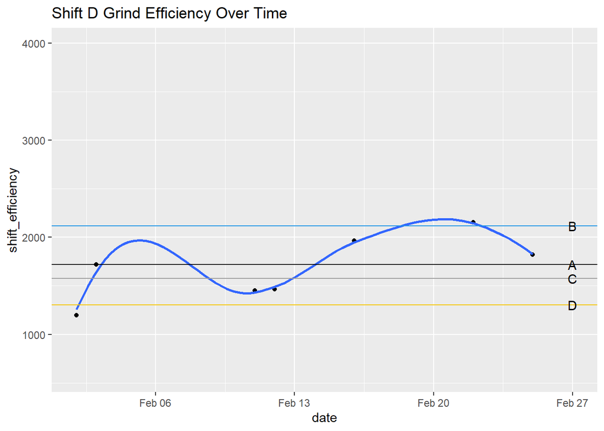

_____________________________________________________________________________________________________________________________________

#### March

March Grind Efficiecy Summary

| shift | pounds | hours | efficiency | shifts | initial | na | err |
| --- | --- | --- | --- | --- | --- | --- | --- |
| A | 169758 | 89.76 | 1891.24 | 15 | 15 | 0 | 0 |
| B | 100855 | 59.82 | 1685.97 | 11 | 16 | 5 | 0 |
| C | 205661 | 135.18 | 1521.39 | 14 | 15 | 1 | 0 |
| D | 128891 | 87.45 | 1473.88 | 10 | 16 | 5 | 1 |

- EFFICIENCY: pounds/hours
- SHIFTS: shifts included in the data
- INITIAL: shifts since 2023
- NA: shifts with missing values
- ERR: shifts with erroneous values

##### SHIFT

###### All

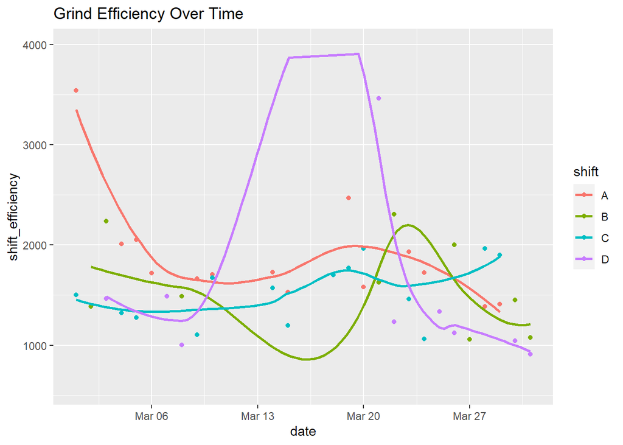

_____________________________________________________________________________________________________________________________________

###### A

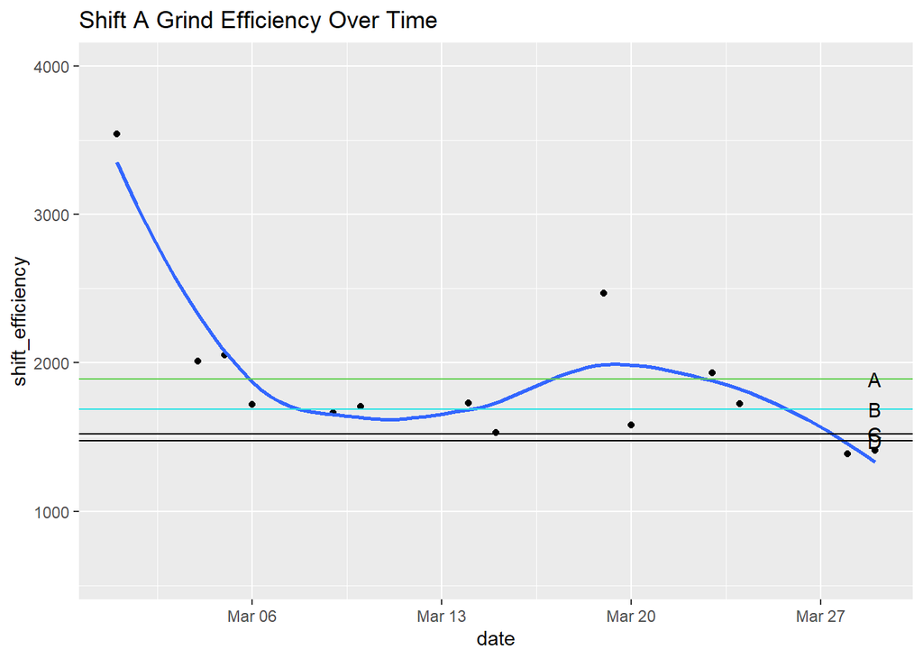

_____________________________________________________________________________________________________________________________________

###### B

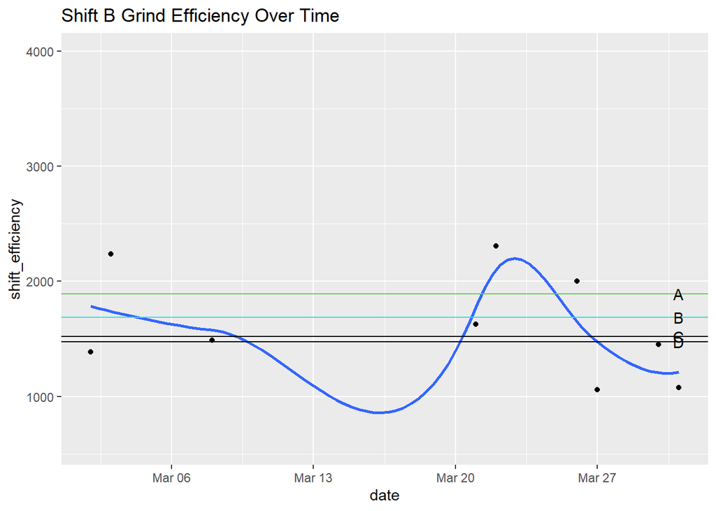

_____________________________________________________________________________________________________________________________________

###### C

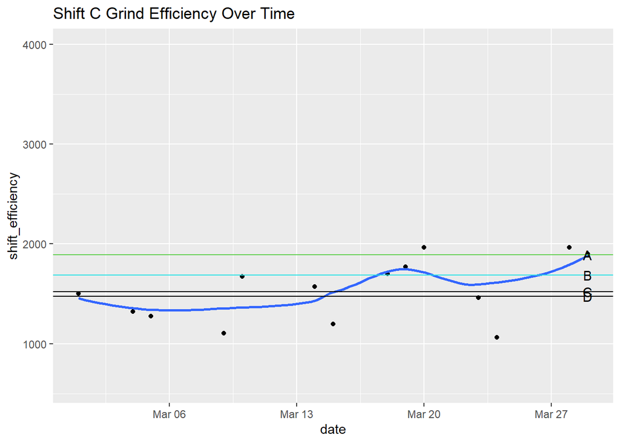

_____________________________________________________________________________________________________________________________________

###### D

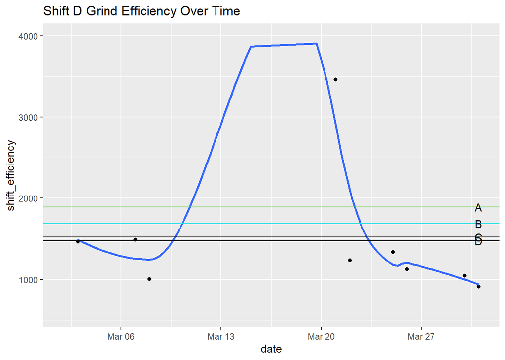

_____________________________________________________________________________________________________________________________________

#### April

April Grind Efficiecy Summary

| shift | pounds | hours | efficiency | shifts | initial | na | err |
| --- | --- | --- | --- | --- | --- | --- | --- |
| A | 120206 | 71.13 | 1689.95 | 11 | 16 | 5 | 0 |
| B | 55352 | 35.76 | 1547.87 | 9 | 14 | 5 | 0 |
| C | 138282 | 87.87 | 1573.71 | 10 | 16 | 6 | 0 |
| D | 95512 | 68.97 | 1384.83 | 9 | 14 | 4 | 1 |

- EFFICIENCY: pounds/hours
- SHIFTS: shifts included in the data
- INITIAL: shifts since 2023
- NA: shifts with missing values
- ERR: shifts with erroneous values

##### SHIFT

###### All

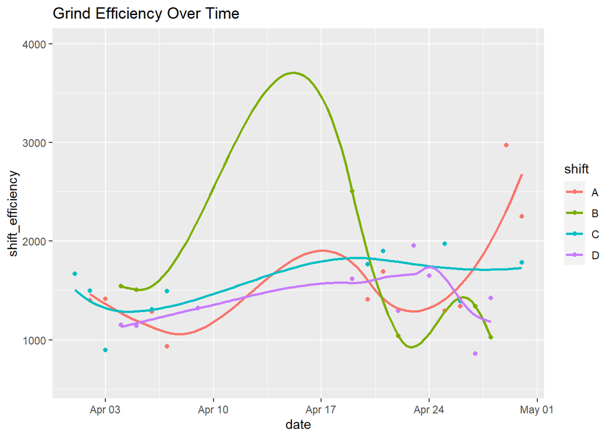

_____________________________________________________________________________________________________________________________________

###### A

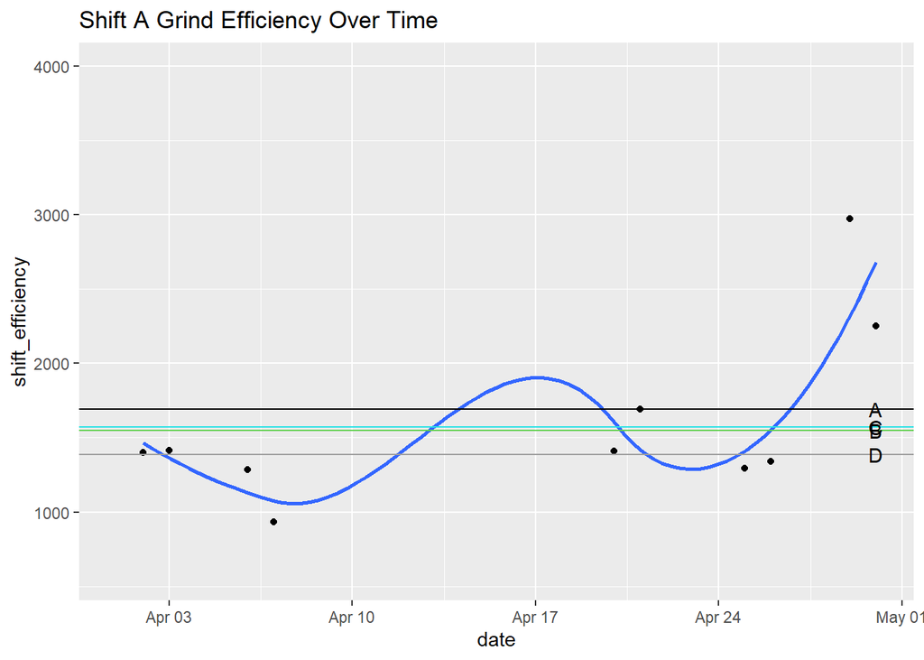

_____________________________________________________________________________________________________________________________________

###### B

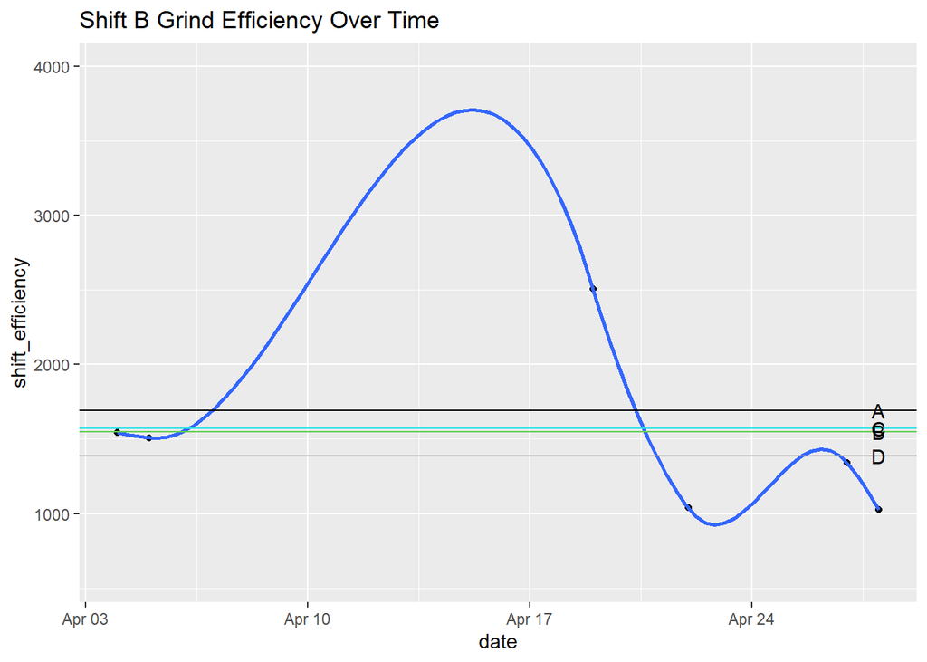

_____________________________________________________________________________________________________________________________________

###### C

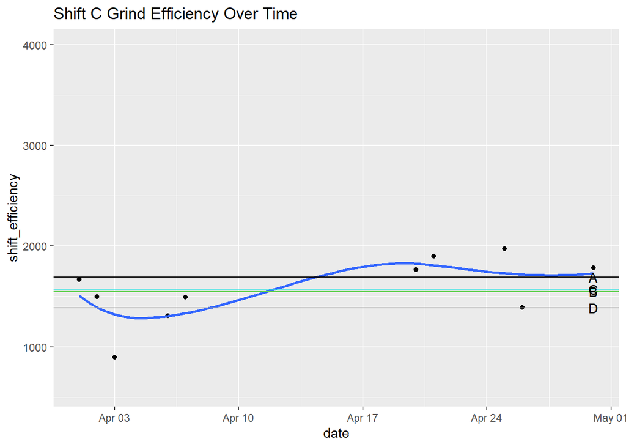

_____________________________________________________________________________________________________________________________________

###### D

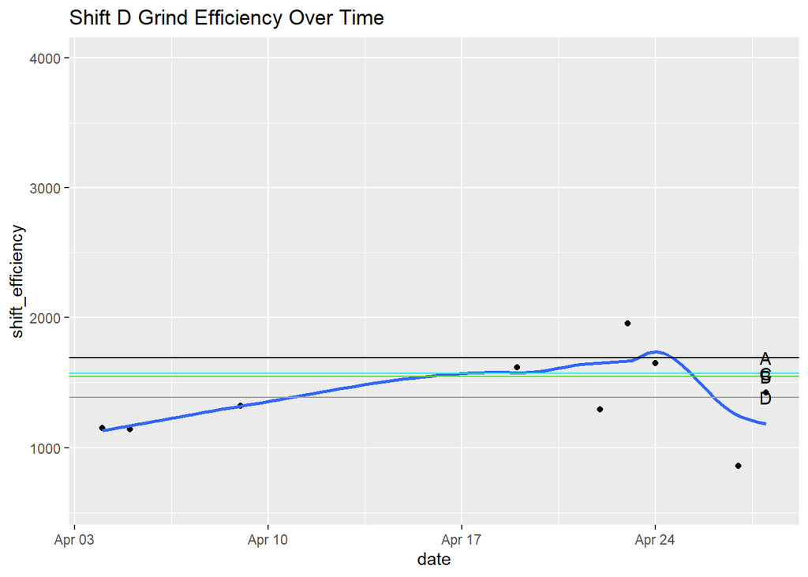

_____________________________________________________________________________________________________________________________________

#### May

May Grind Efficiecy Summary

| shift | pounds | hours | efficiency | shifts | initial | na | err |
| --- | --- | --- | --- | --- | --- | --- | --- |
| A | 133145 | 92.69 | 1436.45 | 12 | 15 | 3 | 0 |
| B | 75134 | 47.65 | 1576.79 | 6 | 16 | 9 | 1 |
| C | 131143 | 90.57 | 1447.97 | 11 | 15 | 2 | 2 |
| D | 135783 | 84.51 | 1606.71 | 10 | 16 | 5 | 1 |

- EFFICIENCY: pounds/hours
- SHIFTS: shifts included in the data
- INITIAL: shifts since 2023
- NA: shifts with missing values
- ERR: shifts with erroneous values

##### SHIFT

###### All

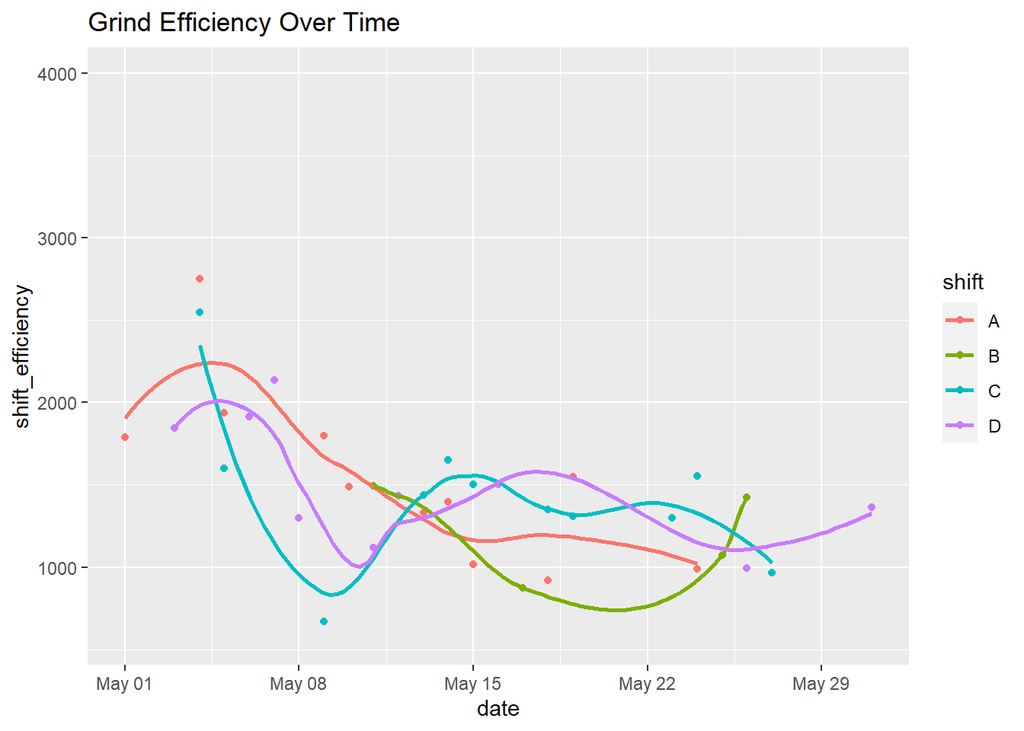

_____________________________________________________________________________________________________________________________________

###### A

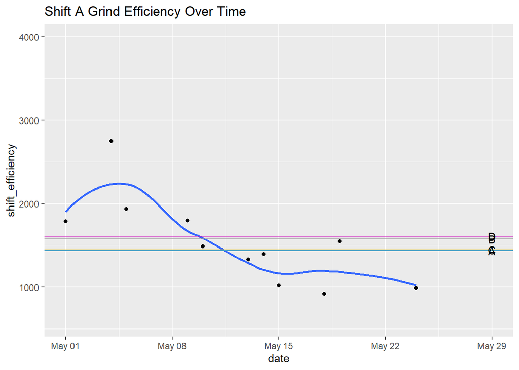

_____________________________________________________________________________________________________________________________________

###### B

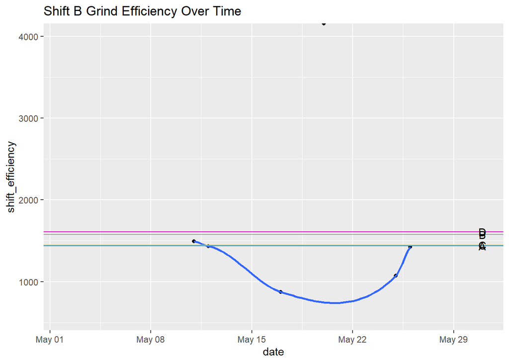

_____________________________________________________________________________________________________________________________________

###### C

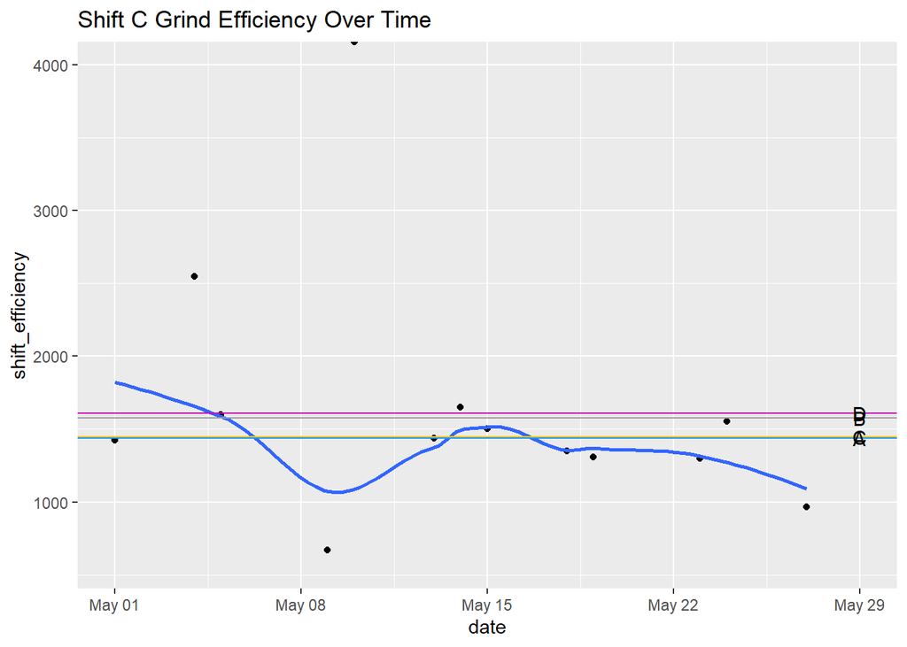

_____________________________________________________________________________________________________________________________________

###### D

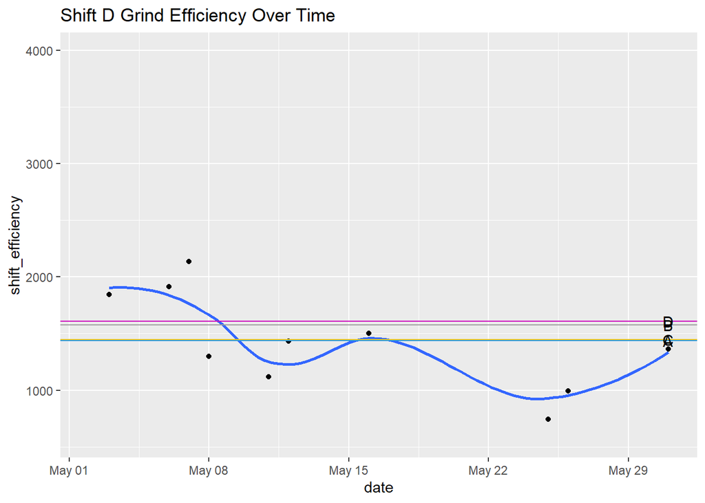

_____________________________________________________________________________________________________________________________________

#### June

June Grind Efficiecy Summary

| shift | pounds | hours | efficiency | shifts | initial | na | err |
| --- | --- | --- | --- | --- | --- | --- | --- |
| A | 117831 | 90.12 | 1307.49 | 12 | 16 | 4 | 0 |
| B | 65146 | 15.24 | 4274.67 | 6 | 14 | 8 | 0 |
| C | 155970 | 113.37 | 1375.76 | 14 | 16 | 1 | 1 |
| D | 62887 | 52.93 | 1188.12 | 7 | 14 | 5 | 2 |

- EFFICIENCY: pounds/hours
- SHIFTS: shifts included in the data
- INITIAL: shifts since 2023
- NA: shifts with missing values
- ERR: shifts with erroneous values

##### SHIFT

###### All

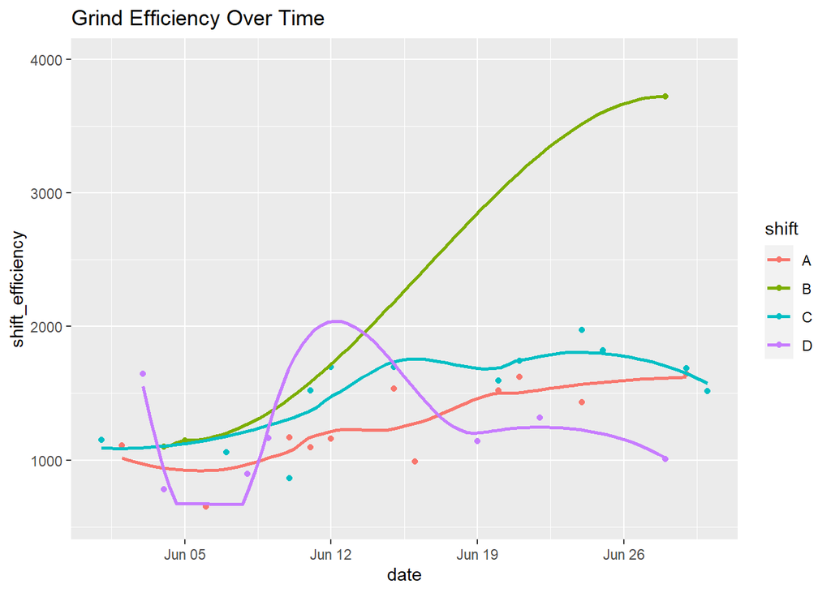

_____________________________________________________________________________________________________________________________________

###### A

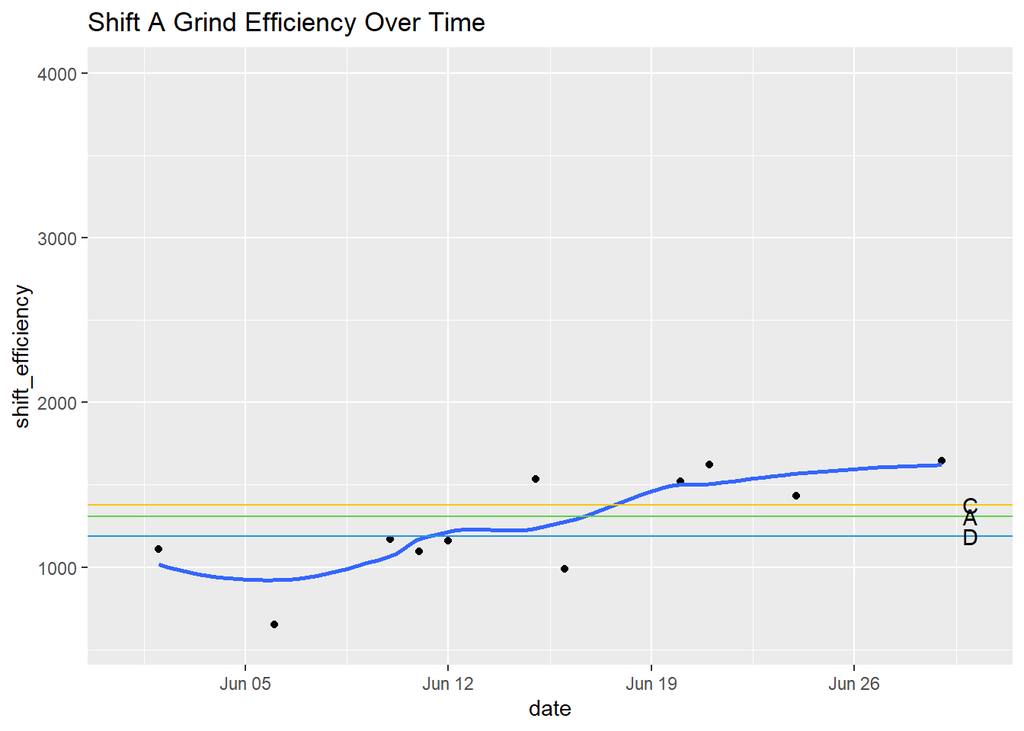

_____________________________________________________________________________________________________________________________________